# 1 Constructing the matrix X

# 3 Minimizing the radiation dose

We use our previous approach to reconstruct the image from different numbers of projections. The angles are as spread out as possible to maximize the information the projections can give us about the image.

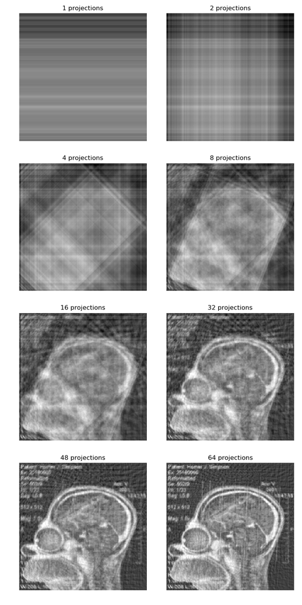

```
Wall time: 21 s
```

```python
%%time

# set up data
Np = 275
y = np.load('hs_tomography/y_195.npy')
alphas = np.load('hs_tomography/alphas_195.npy')

# numbers of projection angles to test
n_projections = [1, 2, 4, 8, 16, 32, 48, 64]

fig, axes = plt.subplots(4, 2, figsize = (8,16))

for n in range(len(n_projections)):
    # pick specified number of angles
    index = [int(np.ceil(len(alphas) * p/n_projections[n])) for p in range(n_projections[n])]
    alphas_sub = alphas[index]

    # collect corresponding measurements from y
    y_sub = []
    for i in index:
        y_sub.extend(y[i*Np : (i+1)*Np])

    # construct matrix and reconstruct image
    X = construct_X(195, alphas_sub, Np).tocsc()
    beta = lsqr(X, np.array(y_sub), atol = 1e-5, btol = 1e-5)[0].reshape(195,195)

    # plot image
    axes.flat[n].imshow(beta, vmin = 0, vmax = 255, interpolation = 'nearest')
    axes.flat[n].set_title('{} projections'.format(n_projections[n])); axes.flat[n].axis('off')

fig.tight_layout()
plt.show()
```

With $32$ projections, you can arguably spot a foreign object in the brain. With $48$ projections, the shape becomes somewhat recognizable, and with $64$ projections it is quite clear.

However, if we try to solve the $48$-projection problem with lower tolerance, the noise we can see above is amplified to very heavy artifacts. This is because in an underconstrained task like this, the solver has too many degrees of freedom and will invent spurious data to reach the best numerical fit.

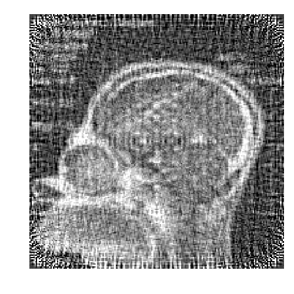

```
Wall time: 46min 1s
```

```python
%%time

# set up data
Np = 275
y = np.load('hs_tomography/y_195.npy')
alphas = np.load('hs_tomography/alphas_195.npy')

# pick the 48 angles
index = [int(np.ceil(len(alphas) * p/48)) for p in range(48)]
alphas_sub = alphas[index]

# collect corresponding measurements from y
y_sub = []
for i in index:
    y_sub.extend(y[i*Np : (i+1)*Np])

# construct matrix and reconstruct image exactly
X = construct_X(195, alphas_sub, Np).tocsc()
beta = lsqr(X, np.array(y_sub), atol = 1e-7, btol = 1e-7)[0].reshape(195,195)

# plot image
fig = plt.figure(figsize = (5,5))
plt.imshow(beta, vmin = 0, vmax = 255, interpolation = 'nearest')
plt.gray(); plt.axis('off'); fig.tight_layout(); plt.show()
```